# **專案一、 主成分分析的原理與實驗**

### 資料介紹 : 利用一組來自義大利三個紅酒製造商的資料，內容包括的 178 支紅酒的 13 種化學成分。

```python
from scipy.io import loadmat
import matplotlib.pyplot as plt
import pandas as pd
import numpy as np
df = pd.read_excel('C:/Users/UX425JA/Desktop/Shallow Machine Learning/wine.xlsx')
df1 = np.array(df)
ratings = np.delete(df1,13,axis=1)
categories = df.columns
categories = categories[0:13]
N = df.shape[0]
print(df)
```

```
     Alcohol  Malic_Acid   Ash  Ash_Alcanity  Magnesium  Total_Phenols  \
0      14.23        1.71  2.43          15.6        127           2.80
1      13.20        1.78  2.14          11.2        100           2.65
2      13.16        2.36  2.67          18.6        101           2.80
3      14.37        1.95  2.50          16.8        113           3.85
4      13.24        2.59  2.87          21.0        118           2.80
..       ...         ...   ...           ...        ...            ...
173    13.71        5.65  2.45          20.5         95           1.68
174    13.40        3.91  2.48          23.0        102           1.80
175    13.27        4.28  2.26          20.0        120           1.59
176    13.17        2.59  2.37          20.0        120           1.65
177    14.13        4.10  2.74          24.5         96           2.05

     Flavanoids  Nonflavanoid_Phenols  Proanthocyanins  Color_Intensity   Hue  \
0          3.06                  0.28             2.29             5.64  1.04
```

[output cut: 25 more lines]

### 觀察前13個變數的相關係數矩陣

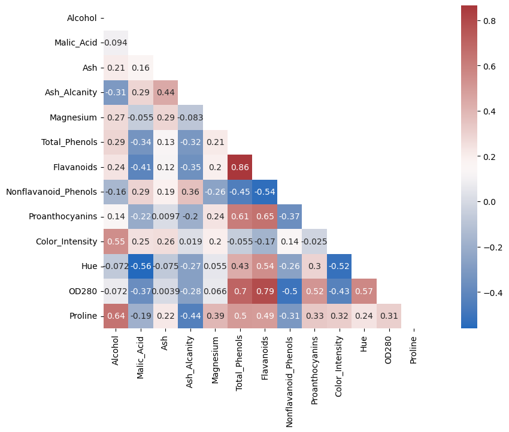

```python
import seaborn
import pandas as pd
df2 = pd.DataFrame(ratings, columns = categories) #弄成Dataframe
R = df2.corr() #相關係數矩陣
mask = np.triu(np.ones_like(R, dtype=bool)) # diagonal mask
plt.figure(figsize=(15, 7))
seaborn.heatmap(R, annot=True, mask = mask, cmap='vlag',square=True)
```

### 關於相關係數的討論:

- Total_Phenols、Flavanoids、OD280與其他變數的相關性普遍較強。
- (Flavanoids、Total_Phenols)和(OD280、Flavanoids)和(OD280、Total_Phenols)的組合有明顯相關。
- 其餘變數的相關性相較沒那麼明顯。

### 繪製原本13個變數及標準化後的盒鬚圖

```
<function matplotlib.pyplot.show(close=None, block=None)>
```

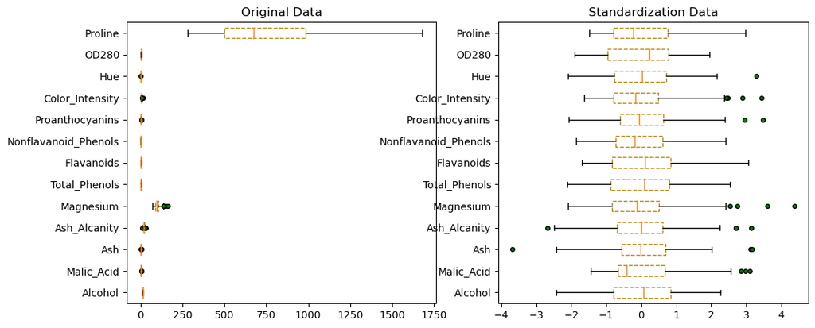

```python
fig,ax = plt.subplots(1,2,figsize=(12,5))
boxprops = dict(linestyle = '--', linewidth = 1,
color = 'darkgoldenrod')
flierprops = dict(marker='o', markerfacecolor = 'green',
markersize = 4, linestyle = 'none')
ax[0].boxplot(ratings, boxprops = boxprops,
flierprops = flierprops,labels = categories, vert = False)
ax[0].set_title('Original Data')
########################################
mu = np.mean(ratings,axis=0)
std = np.std(ratings,axis=0)
ratings_ = (ratings-mu)/std
boxprops = dict(linestyle = '--', linewidth = 1,
color = 'darkgoldenrod')
flierprops = dict(marker='o', markerfacecolor = 'green',
markersize = 4, linestyle = 'none')
ax[1].boxplot(ratings_, boxprops = boxprops,
flierprops = flierprops,labels = categories, vert = False)
ax[1].set_title('Standardization Data')
plt.show
```

### 討論:

- 從原資料的盒鬚圖(左圖)發現，Proline的數字差距及變異程度相差很大，而Magnesium的數字差距與剩餘變數有落差。
- 從標準化後的盒鬚圖(右圖)發現，數字差距與變異程度落差沒左圖大，這樣的情況對主成分分析較有利。

### 繪製特徵值由大而小的分布與Scree Plot

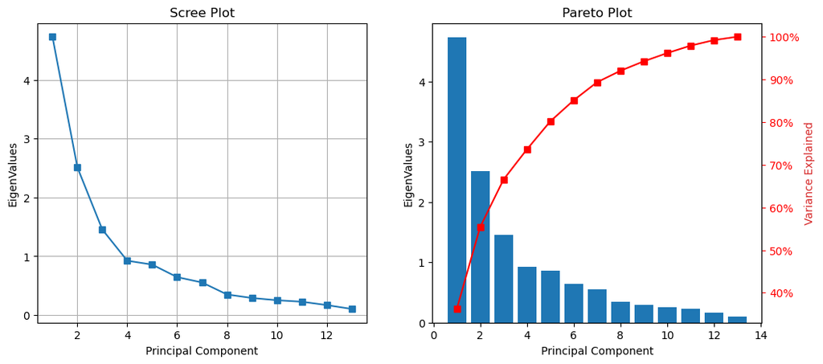

```python
from numpy.linalg import eig
import matplotlib.ticker as mtick
from matplotlib.ticker import PercentFormatter
mu1 = np.mean(ratings_,axis=0)
a = ratings_-mu1
cov = a.T @ a / (N-1) #sigma X
w ,v = eig(cov) #w為特徵值 v為特徵向量
v_id = np.argsort(w)[::-1]
eigval = w[v_id]
eigvec = v[:,v_id]
fig, ax = plt.subplots(1,2,figsize=(12,5))
x = np.arange(1, 1+len(eigval))
ax[0].plot(x, eigval, marker='s') #s是square的意思
ax[0].set_title('Scree Plot')
ax[0].grid(True) #顯示網格線
ax[0].set_ylabel('EigenValues')
ax[0].set_xlabel('Principal Component')
############################################################
x = np.arange(1, 1+len(eigval))
ax[1].bar(x, eigval) #柱狀圖
ax2 = ax[1].twinx() #ax1和ax2用同個x軸
y = (eigval.cumsum()/sum(eigval))*100 #.cumsum()累積加法
ax2.plot(x, y, marker='s', color='red', lw=1.5)
ax2.tick_params(axis='y', colors='red')
ax2.yaxis.set_major_formatter(PercentFormatter())
ax2.set_title('Pareto Plot')
ax[1].set_xlabel('Principal Component')
ax2.yaxis.set_label_position('right')
ax2.set_ylabel('Variance Explained',color='tab:red')
ax[1].yaxis.set_label_position('left')
ax[1].set_ylabel('EigenValues')
```

### 討論:

- 由左圖及右圖的柱狀圖可看出特徵值確實由大而小排列。
- 最大特徵值的變異解釋(貢獻度)大約3.6成，第二大特徵值的約2成，第三大特徵值的約1成。
- 特徵值由大而小排列就是排出貢獻度大小的排序，因為各個特徵值就是新變數各個的變異數，例如最大的特徵值是Z1的變異數， 第二大的特徵值是Z2的變異數，總變異數不變的前提下，Z1貢獻度最高。
- 最大只有3.6成，可能會需要多搭配其他Z值才會有較好的分群。

### 不考慮標籤，繪製主成分散佈圖，並比較有無標準化的差別

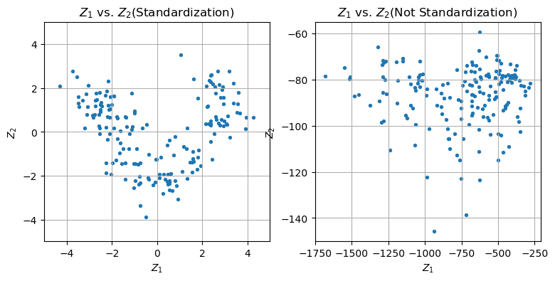

```python
#有標準化
fig, ax = plt.subplots(1,2,figsize=(9,4))
ax[0].set_xlim([-5,5])
ax[0].set_ylim([-5,5])
ax[0].set_xlabel('$Z_1$')
ax[0].set_ylabel('$Z_2$')
ax[0].grid(True)
Z = eigvec.T @ ratings_.T
Z1 = Z[0,:]
Z2 = Z[1,:]
ax[0].scatter(Z1,Z2,s=8)
ax[0].set_title('$Z_1$ vs. $Z_2$(Standardization) ')
###################################
#沒標準化
mu2 = np.mean(ratings,axis=0)
a1 = ratings-mu2
cov1 = a1.T @ a1 / (N-1)
w1,v1 = eig(cov1)
v1_id = np.argsort(w1)[::-1]
eigval1 = w1[v1_id]
eigvec1 = v1[:,v1_id]
Z_not = eigvec1.T @ ratings.T
Z1_not = Z_not[0,:]
Z2_not = Z_not[1,:]
ax[1].scatter(Z1_not,Z2_not,s=8)
ax[1].set_title('$Z_1$ vs. $Z_2$(Not Standardization) ')
ax[1].set_xlabel('$Z_1$')
ax[1].set_ylabel('$Z_2$')
ax[1].grid(True)
```

### 討論:

- 經過主成分分析，並選貢獻度前二大的Z1、Z2當作新圖形的X、Y軸後，可以發現左圖相較右圖有更多明顯集中的群體，可以大致看到散佈點較集中的會有三群。
- 右圖為沒做標準化的結果，可以發現由於變數的變異、數字差距，導致其他變數的變異容易被覆蓋，大致看到只有一個群體

### 考慮標籤(資料第14行)，並為散佈圖的每個資料點上色分群

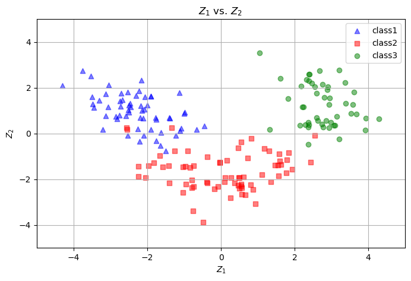

```python
fig, ax = plt.subplots(figsize=(8,5))
cluster = df1[:,13]
ax.set_xlim([-5,5])
ax.set_ylim([-5,5])
ax.set_xlabel('$Z_1$')
ax.set_ylabel('$Z_2$')
ax.grid(True)
merge = np.vstack((Z1,Z2,cluster.T))
for i in range(merge.shape[1]) :
    if merge[2,i] == 1:
        s1 = ax.scatter(merge[0,i],merge[1,i],c='blue',marker="^",alpha=0.5)
    elif merge[2,i] == 2:
        s2 = ax.scatter(merge[0,i],merge[1,i],c='red',marker="s",alpha=0.5)
    else :
        s3 = ax.scatter(merge[0,i],merge[1,i],c='green',alpha=0.5)
ax.set_title('$Z_1$ vs. $Z_2$ ')
ax.legend((s1,s2,s3),('class1','class2','class3'),loc=1)
```

### 討論:

- 上色後分群效果更加明顯，Z1的正負可以大致分出class1、class3，Z2的正負可以再分出class2。

### 考慮標籤，為散佈圖的每個資料點上色分群(增加第三個特徵向量Z3)

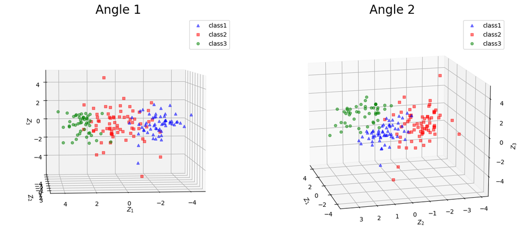

```python
from mpl_toolkits.mplot3d import Axes3D
Z3 = Z[2,:]
merge3d = np.vstack((Z1,Z2,Z3,cluster.T))
plt.figure(figsize=(15,10))
ax3d = plt.subplot(1,2,1, projection='3d')
for i in range(merge3d.shape[1]) :
    if merge3d[3,i] == 1:
        d1 = ax3d.scatter(merge3d[0,i],merge3d[1,i],merge3d[2,i],c='blue',marker="^",alpha=0.5)
    elif merge3d[3,i] == 2:
        d2 = ax3d.scatter(merge3d[0,i],merge3d[1,i],merge3d[2,i],c='red',marker="s",alpha=0.5)
    else :
        d3 = ax3d.scatter(merge3d[0,i],merge3d[1,i],merge3d[2,i],c='green',alpha=0.5)
ax3d.legend((d1,d2,d3),('class1','class2','class3'),loc=1)
ax3d.set_xlabel('$Z_1$')
ax3d.set_ylabel('$Z_2$')
ax3d.set_zlabel('$Z_3$')
ax3d.view_init(elev=5,azim=85)
ax3d.set_title('Angle 1',fontsize=20)
##########################################################
ax3d2 = plt.subplot(1,2,2, projection='3d')
for i in range(merge3d.shape[1]) :
    if merge3d[3,i] == 1:
        d1 = ax3d2.scatter(merge3d[0,i],merge3d[1,i],merge3d[2,i],c='blue',marker="^",alpha=0.5)
    elif merge3d[3,i] == 2:
        d2 = ax3d2.scatter(merge3d[0,i],merge3d[1,i],merge3d[2,i],c='red',marker="s",alpha=0.5)
    else :
        d3 = ax3d2.scatter(merge3d[0,i],merge3d[1,i],merge3d[2,i],c='green',alpha=0.5)
ax3d2.legend((d1,d2,d3),('class1','class2','class3'),loc=1)
ax3d2.set_xlabel('$Z_1$')
ax3d2.set_ylabel('$Z_2$')
ax3d2.set_zlabel('$Z_3$')
ax3d2.view_init(elev=15,azim=165)
ax3d2.set_title('Angle 2',fontsize=20)
```

### 討論:

- 由左右圖的角度看可以發現加入Z3的分群效果稍好，但效益不大。
- class1在Z1低、Z2高、Z3低的位置。
- class2在Z1不明顯、Z2低、Z3高的位置。
- class3在Z1高、Z2高、Z3低的位置。
- 可能是因為Z3的變異程度不夠大，導致分群效果沒有更加顯著。

### 從Z1及Z2的組成係數看出原變數哪個比較重要 ? 再與原變數間的相關係數圖做對照

```python
#Z1和Z2組合變數的係數
for i in range(ratings.shape[1]):
    print('Z1_',categories[i],':',eigvec[:,0][i])
    print('Z2_',categories[i],':',eigvec[:,1][i])
```

```
Z1_ Alcohol : -0.1443293954060116
Z2_ Alcohol : 0.4836515478172144
Z1_ Malic_Acid : 0.2451875802572207
Z2_ Malic_Acid : 0.22493093462784447
Z1_ Ash : 0.00205106144437129
Z2_ Ash : 0.31606881402531567
Z1_ Ash_Alcanity : 0.23932040548753505
Z2_ Ash_Alcanity : -0.0105905022881913
Z1_ Magnesium : -0.14199204195298723
Z2_ Magnesium : 0.29963400323786243
Z1_ Total_Phenols : -0.39466084506663
Z2_ Total_Phenols : 0.06503951181927954
Z1_ Flavanoids : -0.42293429671005905
Z2_ Flavanoids : -0.003359812100307758
Z1_ Nonflavanoid_Phenols : 0.29853310295471513
Z2_ Nonflavanoid_Phenols : 0.028779488112986737
Z1_ Proanthocyanins : -0.3134294883076886
Z2_ Proanthocyanins : 0.03930172228973273
Z1_ Color_Intensity : 0.08861670472472291
Z2_ Color_Intensity : 0.5299956720700432
Z1_ Hue : -0.2967145635863816
Z2_ Hue : -0.27923514792428195
Z1_ OD280 : -0.3761674107387128
Z2_ OD280 : -0.16449619283578465
Z1_ Proline : -0.2867522268968048
Z2_ Proline : 0.3649028317980826
```

```python
#Z1和Z2組合變數的係數中，數字(權重)前三大、後三大的值及變數
n1 = np.argsort(abs(eigvec[:,0]))[::-1] #Z1
m1 = eigvec[:,0][n1]
m1c = categories[n1]
n2 = np.argsort(abs(eigvec[:,1]))[::-1] #Z2
m2 = eigvec[:,1][n2]
m2c = categories[n2]
n11 = np.argsort(abs(eigvec[:,0]))[::1] #Z1
m11 = eigvec[:,0][n11]
m1c1 = categories[n11]
n21 = np.argsort(abs(eigvec[:,1]))[::1] #Z2
m21 = eigvec[:,1][n21]
m2c1 = categories[n21]
for i in range(3) :
    print('top',i+1,'Z1_',m1c[i],':',m1[i])
for i in range(3) :
    print('top',i+1,'Z2_',m2c[i],':',m2[i])
for i in range(3) :
    print('bottom',i+1,'Z1_',m1c1[i],':',m11[i])
for i in range(3) :
    print('bottom',i+1,'Z2_',m2c1[i],':',m21[i])
```

```
top 1 Z1_ Flavanoids : -0.42293429671005905
top 2 Z1_ Total_Phenols : -0.39466084506663
top 3 Z1_ OD280 : -0.3761674107387128
top 1 Z2_ Color_Intensity : 0.5299956720700432
top 2 Z2_ Alcohol : 0.4836515478172144
top 3 Z2_ Proline : 0.3649028317980826
bottom 1 Z1_ Ash : 0.00205106144437129
bottom 2 Z1_ Color_Intensity : 0.08861670472472291
bottom 3 Z1_ Magnesium : -0.14199204195298723
bottom 1 Z2_ Flavanoids : -0.003359812100307758
bottom 2 Z2_ Ash_Alcanity : -0.0105905022881913
bottom 3 Z2_ Nonflavanoid_Phenols : 0.028779488112986737
```

### 討論:

- 我把Z1和Z2組成係數中，權重占比比較高的原變數抓出來，因為權重高的變數越有可能是是區分的關鍵。
- Z1前三大的權重分別為'Flavanoids'(-0.4229343)、'Total_Phenols'(-0.39466085)及'OD280'(-0.37616741)
- Z2前三大的權重分別為'Color_Intensity'(0.52999567)、'Alcohol'(0.48365155)、'Proline'(0.36490283)
- Z1後三大的權重分別為'Ash'(0.00205106)、'Color_Intensity'(0.0886167)、'Magnesium'(-0.14199204)
- Z2後三大的權重分別為'Flavanoids'(-0.00335981)、'Ash_Alcanity'(-0.0105905)、'Nonflavanoid_Phenols'(0.02877949)
- 我認為'Flavanoids'、'Total_Phenols'、'OD280'是重要的變數，因為是貢獻度最高的特徵向量中權重偏高的變數，也與我一開始對相關係數圖的初步分析相同。  
  </font>
- 我認為'Ash'是最不重要的變數，因為是貢獻度最高的特徵向量中權重最低的變數，且相關係數圖中的色系幾乎為淺色系。